# TP : Location de vélos en libre-service

# ETUDIANT : MATHIEU LE RUYET

L’organisme de gestion d’un système de location de vélos en libre-service (ex: Vélib) cherche à organiser ses équipes de maintenance pour répondre au mieux à la demande de ses clients.  
**Votre mission :**  
Réaliser un modèle permettant de prédire le nombre de vélos loués par heure

**Objectifs de ce TP :**

- Dérouler la méthodologie du « POC » sur une problématique donnée
- Utiliser les grandes familles d’algorithmes présentées en cours
- Mettre en place les pratiques adaptées pour l’entraînement d’un modèle

**Format du rendu :**

- Le code fourni doit être écrit en Python et en format Jupyter Notebook.
- Votre notebook doit contenir du code, du texte et des graphiques. Vous devez envoyer l’export HTML de votre notebook avec toutes les cellules exécutées. Assurez-vous que le fichier produit est lisible.
- Vous pouvez utiliser n’importe quelle libraire Python que vous jugez nécessaire.
- Il ne s’agit pas d’une competition de type Kaggle : vous ne serez pas uniquement évalué sur la performance du modèle mais plutôt sur la pertinence et la justification de vos choix ainsi que sur la qualité de vos explications.

Voici un descriptif de l'ensemble des variables :

- *instant* - index du relevé
- *dteday* - date du relevé
- *season* - 1 = printemps , 2 = été, 3 = automne, 4 = hiver
- *mnth* - mois du relevé (entre 1 et 12)
- *hr* - heure du relevé (entre 0 et 23)
- *holiday* – indique si le jour est un jour de vacances scolaires
- *weekday* - day of the week
- *weather* - 1: Dégagé à nuageux, 2 : Brouillard, 3 : Légère pluie ou neige, 4 : Fortes averses ou neiges
- *temp* – température en degrés Celsius
- *atemp* – température ressentie en degrés Celsius
- *humidity* – taux d’humidité
- *windspeed* – vitesse du vent
- *casual* - nombre de locations d’usagers non abonnés
- *registered* – nombre de locations d’usagers abonnés
- *count* – nombre total de locations de vélos

## Questions préalables

**1) Quelle famille d’algorithmes semble adaptée à la mission qui vous a été confiée ?**

On souhaite prédire le nombre de vélos loués par heure. Nous avons une cible qui est une variable quantitative que l'on peut considérer comme continue. Nous connaissons aussi les étiquettes et avons un historique des données. A première vue, on s'oriente donc plutôt sur des algorithmes supervisés de type régression qui répondent à ces critères.

**2) Quelles variables sont susceptibles de constituer une « cible » ?**

La varialbe count (nombre total de locations de vélos) est notre cible que l'on veut prédire. Il lui est associé hr( heure du relevé) car la variable count est pour une heure donnée.

## Imports

Vous ajouterez les éventuels imports supplémentaires nécessaires à la cellule ci-dessous :

```python
import pandas as pd
import numpy as np

import matplotlib.pyplot as plt
import seaborn as sns
%matplotlib inline
```

## Extraction et prise en main de la donnée

Dans cette partie, on va commencer par lire les données et vérifier leur intégrité. C'est également le moment de s'assurer qu'on comprend bien l'ensemble des champs que l'on a à disposition.

```python
df = pd.read_csv("../data/input/velo.csv")
df.head(20)
```

|  | instant | dteday | season | mnth | hr | holiday | weekday | weathersit | temp | atemp | hum | windspeed | casual | registered | cnt |
| --- | --- | --- | --- | --- | --- | --- | --- | --- | --- | --- | --- | --- | --- | --- | --- |
| 0 | 1 | 2011-01-01 | 1 | 1 | 0 | 0 | 6 | 1 | 9.84 | 14.395 | 81.0 | 0.0000 | 3 | 13 | 16 |
| 1 | 2 | 2011-01-01 | 1 | 1 | 1 | 0 | 6 | 1 | 9.02 | 13.635 | 80.0 | 0.0000 | 8 | 32 | 40 |
| 2 | 3 | 2011-01-01 | 1 | 1 | 2 | 0 | 6 | 1 | 9.02 | 13.635 | 80.0 | 0.0000 | 5 | 27 | 32 |
| 3 | 4 | 2011-01-01 | 1 | 1 | 3 | 0 | 6 | 1 | 9.84 | 14.395 | 75.0 | 0.0000 | 3 | 10 | 13 |
| 4 | 5 | 2011-01-01 | 1 | 1 | 4 | 0 | 6 | 1 | 9.84 | 14.395 | 75.0 | 0.0000 | 0 | 1 | 1 |
| 5 | 6 | 2011-01-01 | 1 | 1 | 5 | 0 | 6 | 2 | 9.84 | 12.880 | 75.0 | 6.0032 | 0 | 1 | 1 |
| 6 | 7 | 2011-01-01 | 1 | 1 | 6 | 0 | 6 | 1 | 9.02 | 13.635 | 80.0 | 0.0000 | 2 | 0 | 2 |
| 7 | 8 | 2011-01-01 | 1 | 1 | 7 | 0 | 6 | 1 | 8.20 | 12.880 | NaN | 0.0000 | 1 | 2 | 3 |
| 8 | 9 | 2011-01-01 | 1 | 1 | 8 | 0 | 6 | 1 | 9.84 | 14.395 | 75.0 | 0.0000 | 1 | 7 | 8 |
| 9 | 10 | 2011-01-01 | 1 | 1 | 9 | 0 | 6 | 1 | 13.12 | 17.425 | 76.0 | 0.0000 | 8 | 6 | 14 |
| 10 | 11 | 2011-01-01 | 1 | 1 | 10 | 0 | 6 | 1 | 15.58 | 19.695 | 76.0 | 16.9979 | 12 | 24 | 36 |
| 11 | 12 | 2011-01-01 | 1 | 1 | 11 | 0 | 6 | 1 | 14.76 | 16.665 | NaN | 19.0012 | 26 | 30 | 56 |
| 12 | 13 | 2011-01-01 | 1 | 1 | 12 | 0 | 6 | 1 | 17.22 | 21.210 | 77.0 | 19.0012 | 29 | 55 | 84 |
| 13 | 14 | 2011-01-01 | 1 | 1 | 13 | 0 | 6 | 2 | 18.86 | 22.725 | NaN | 19.9995 | 47 | 47 | 94 |
| 14 | 15 | 2011-01-01 | 1 | 1 | 14 | 0 | 6 | 2 | 18.86 | 22.725 | 72.0 | 19.0012 | 35 | 71 | 106 |
| 15 | 16 | 2011-01-01 | 1 | 1 | 15 | 0 | 6 | 2 | 18.04 | 21.970 | NaN | 19.9995 | 40 | 70 | 110 |
| 16 | 17 | 2011-01-01 | 1 | 1 | 16 | 0 | 6 | 2 | 17.22 | 21.210 | 82.0 | 19.9995 | 41 | 52 | 93 |
| 17 | 18 | 2011-01-01 | 1 | 1 | 17 | 0 | 6 | 2 | 18.04 | 21.970 | 82.0 | 19.0012 | 15 | 52 | 67 |
| 18 | 19 | 2011-01-01 | 1 | 1 | 18 | 0 | 6 | 3 | 17.22 | 21.210 | 88.0 | 16.9979 | 9 | 26 | 35 |
| 19 | 20 | 2011-01-01 | 1 | 1 | 19 | 0 | 6 | 3 | 17.22 | 21.210 | 88.0 | 16.9979 | 6 | 31 | 37 |

```python
df.dtypes
```

```
instant         int64
dteday         object
season          int64
mnth            int64
hr              int64
holiday         int64
weekday         int64
weathersit      int64
temp          float64
atemp         float64
hum           float64
windspeed     float64
casual          int64
registered      int64
cnt             int64
dtype: object
```

```python
df.describe()
```

|  | instant | season | mnth | hr | holiday | weekday | weathersit | temp | atemp | hum | windspeed | casual | registered | cnt |
| --- | --- | --- | --- | --- | --- | --- | --- | --- | --- | --- | --- | --- | --- | --- |
| count | 17379.0000 | 17379.000000 | 17379.000000 | 17379.000000 | 17379.000000 | 17379.000000 | 17379.000000 | 17379.000000 | 17379.000000 | 15715.000000 | 17379.000000 | 17379.000000 | 17379.000000 | 17379.000000 |
| mean | 8690.0000 | 2.501640 | 6.537775 | 11.546752 | 0.028770 | 3.003683 | 1.425283 | 20.376474 | 23.788755 | 62.774038 | 12.736540 | 35.676218 | 153.786869 | 189.463088 |
| std | 5017.0295 | 1.106918 | 3.438776 | 6.914405 | 0.167165 | 2.005771 | 0.639357 | 7.894801 | 8.592511 | 19.321135 | 8.196795 | 49.305030 | 151.357286 | 181.387599 |
| min | 1.0000 | 1.000000 | 1.000000 | 0.000000 | 0.000000 | 0.000000 | 1.000000 | 0.820000 | 0.000000 | 0.000000 | 0.000000 | 0.000000 | 0.000000 | 1.000000 |
| 25% | 4345.5000 | 2.000000 | 4.000000 | 6.000000 | 0.000000 | 1.000000 | 1.000000 | 13.940000 | 16.665000 | 48.000000 | 7.001500 | 4.000000 | 34.000000 | 40.000000 |
| 50% | 8690.0000 | 3.000000 | 7.000000 | 12.000000 | 0.000000 | 3.000000 | 1.000000 | 20.500000 | 24.240000 | 63.000000 | 12.998000 | 17.000000 | 115.000000 | 142.000000 |
| 75% | 13034.5000 | 3.000000 | 10.000000 | 18.000000 | 0.000000 | 5.000000 | 2.000000 | 27.060000 | 31.060000 | 78.500000 | 16.997900 | 48.000000 | 220.000000 | 281.000000 |
| max | 17379.0000 | 4.000000 | 12.000000 | 23.000000 | 1.000000 | 6.000000 | 4.000000 | 41.000000 | 50.000000 | 100.000000 | 56.996900 | 367.000000 | 886.000000 | 977.000000 |

```python
# Vérification du nombre de valeurs manquantes
nb_na = df.isna().sum()
```

```python
na_percent = (nb_na / len(df)) * 100
na_percent
# Seulement 10% de valeurs manquantes pour hum
```

```
instant       0.000000
dteday        0.000000
season        0.000000
mnth          0.000000
hr            0.000000
holiday       0.000000
weekday       0.000000
weathersit    0.000000
temp          0.000000
atemp         0.000000
hum           9.574774
windspeed     0.000000
casual        0.000000
registered    0.000000
cnt           0.000000
dtype: float64
```

**3) A partir de ces analyses ainsi que d'analyses additionnelles dont le code sera exécuté ci-dessous, quelles remarques pouvez-vous faire sur la qualité de données ? Le descriptif des variables vous paraît-il complet et exact ?**

La variable instant correspond à l'index du relevé. Il y a 17379 observations pour cette variable. On remarque que les autres variables ont le même nombre d'observations sauf pour la variable humid qui en a seulement 15715. La complétude est de 100% sauf pour cette variable. Cela est confirmé par le bloc de vérification que j'ai ajouté avec 1664 observations. Il est aussi assez surprenant de voir que la variable temp et atemp n'ont pas de valeurs négatives. Le minimum est de 0.82 et 0.00 respectivement. Pour Les autres variables les valeurs minimales et maximales semblent cohérentes. Il manque l'unité pour certaines variables comme humidity and windspeed. humidity est un taux donc on comprend qu'il s'agit d'un pourcentage pour windspeed on peut supposer qu'il s'agit de km/h mais cela n'est pas précisé. Ces relevés ont été sur une plage horaire d'une heure. Il n'est pas précisé si les appareils mesurent en continue et renvoie une moyenne sur l'heure ou si la mesure est prise à un instant T de l'heure et que le timestamp correspond au début de l'heure. Si on veut utiliser notre modèle pour faire des prédictions en temps réel cela peut poser problème. La variable weathersit est nommée weather dans le descriptif. Il y semble aussi avoir une erreur sur les saisons. l'instant 1 qui a la date 2011-01-01 a la saison 1 mais le descriptif indique printemps pour la saison 1 or le 1er janvier est en hiver. La source des données n'est pas indiquée. Est ce que les données proviennent d'une seule station ?

Concernant le jour de la semaine celui-ci peut varier en fonction des pays. Ici on peut supposer que 0 correspond au dimanche et 6 au samedi. Il faudrait compléter le descriptif avec ces informations pour lever les ambiguïtés.

## Préparation

**4) Quelles sont les variables catégorielles ? Les variables numériques ? En complétant le code ci-dessous, vous vous assurerez du bon typage de la donnée à traiter.**

```python
# Des variables catégorielles ont été encodées en numérique dans ce jeu de données.
# On peut aussi mettre la variable hr qui n'est pas une mesure dans cette liste.
cat_vars = ["season","mnth","hr", "holiday","weekday","weathersit"]
# Sélectionner uniquement les colonnes numériques pour la matrice de corrélation
numerical_df = df.select_dtypes(include=['int64', 'float64'])
```

```python
for c in cat_vars:
    df[c] = df[c].astype('category')
```

On garde les variables qui sont des mesures comme numériques elles ont le type float et int. temp float64 atemp float64 hum float64 windspeed float64 casual int64 registered int64 cnt int64.

Les variables encodées sont catégorielles ainsi que l'heure, je les ai listées dans cat_vars.

## Exploration

**5) Que pouvez-vous analyser à partir des graphiques ci-dessous ?**

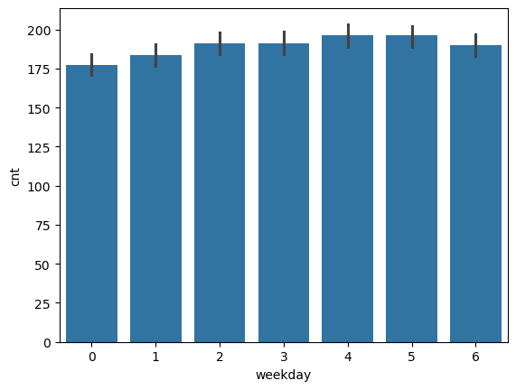

```python
sns.barplot(x="weekday", y="cnt", data=df, estimator=np.mean)
plt.show()
```

On constate que la distribution de la moyenne du nombre de location de vélos est assez uniforme. Le jour de la semaine semble avoir peut d'influence même s'il y a en moyenne moins de location le lundi, samedi, dimanche.

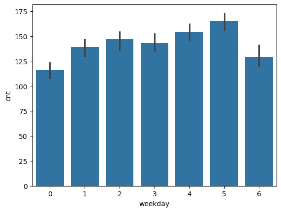

```python
sns.barplot(x="weekday", y="cnt", data=df, estimator=np.median)
plt.show()
```

La mediane permet d'accentuer les différences entre les jours. On constate qu'il y'a moins de location le weekend. Il semblerait qu'il y a une augmentation au cours de la semaine avec la mediane maximale atteinte le vendredi, jour 5.

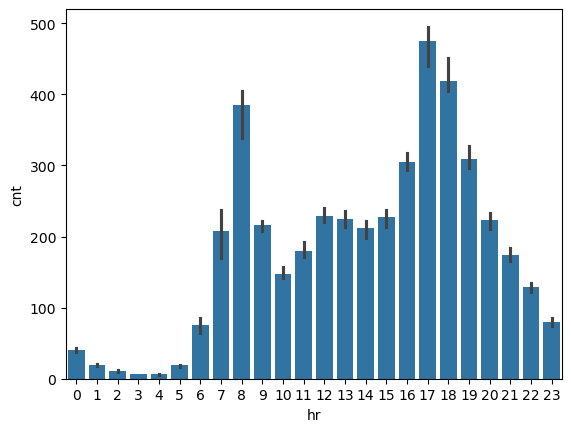

```python
sns.barplot(x="hr", y="cnt", data=df, estimator=np.median)
plt.show()
```

Ce graphique nous indique le nombre de location médian en fonction de l'heure. La distribution est bimodale avec un premier pic autour de 8h suivi d'un autre autour de 17h. Elle montre que la location suit un phénomène cyclique.

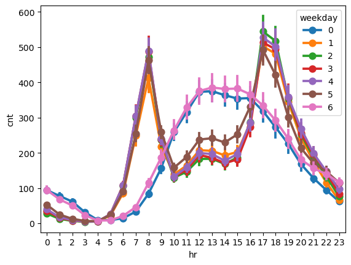

```python
sns.pointplot(data=df, x='hr', y='cnt', hue='weekday')
plt.show()
```

Le nombre median de location par heure est désormais affiché par jour. Les jours ouvrables gardent cette bimodalité tandis que le samedi et le dimanche ont un pic plus applatit entre 12h et 15h. Les heures de creux sont toujours entre minuit et 7h du matin.

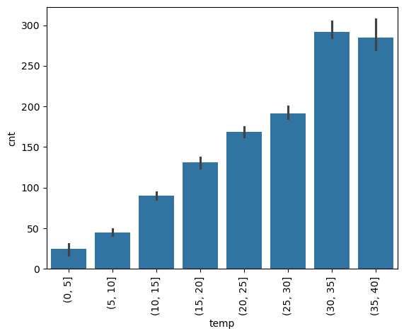

```python
temp_range = range(0, round(df["temp"].max()), 5)
temp_binned = pd.cut(df["temp"], bins=temp_range)
temp_plot = sns.barplot(x=temp_binned, y=df["cnt"], estimator=np.median)
plt.xticks(rotation=90)
plt.show()
```

La distriibution du nombre de location en fonction de la température montre une tendance très nette. Plus la température augmente plus le nombre de location augmente, jusqu'à 30-35°. Jusqu'à 40° le nombre de location reste très élévé, avec environ 100 locations de plus que lorsqu'il fait entre 25-30°. Cela laisse penser que ce type de mobilité est plus agréable que les autres modes de déplacement en période de forte chaleur.

**6) Montrez des graphiques supplémentaires pertinents vous permettant de mieux comprendre les facteurs d'impact sur le nombre de vélos loués. Pour chacun de ces graphiques vous proposerez une analyse.**

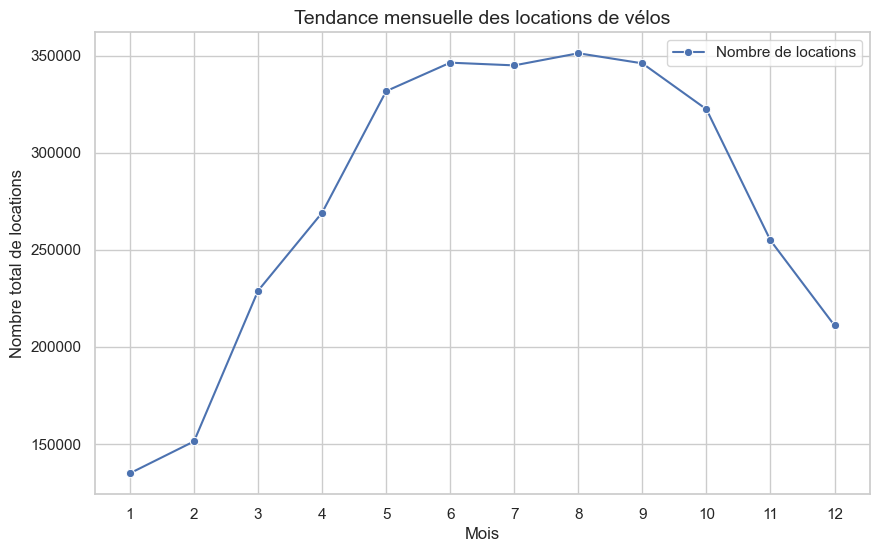

```python
# Importer les bibliothèques nécessaires
import pandas as pd
import matplotlib.pyplot as plt
import seaborn as sns


# Agrégation du nombre total de locations par mois
monthly_trends = df.groupby('mnth')['cnt'].sum().reset_index()

# Configuration du style des graphiques
sns.set(style="whitegrid")

# Création du graphique
plt.figure(figsize=(10, 6))  # Taille de la figure
sns.lineplot(
    data=monthly_trends,
    x='mnth',
    y='cnt',
    marker='o',  # Marqueurs pour chaque point
    color='b',   # Couleur de la ligne
    label='Nombre de locations'
)

# Ajouter des titres et labels
plt.title('Tendance mensuelle des locations de vélos', fontsize=14)
plt.xlabel('Mois', fontsize=12)
plt.ylabel('Nombre total de locations', fontsize=12)
plt.xticks(range(1, 13))  # Afficher tous les mois de 1 à 12

# Ajouter une grille pour une meilleure lisibilité
plt.grid(True)

# Afficher le graphique
plt.show()
```

La distribution des locations de vélo selon le mois présente une certaine saisonnalité. Les mois les plus froids 1, 2, 12 soit janvier, février et décembre un nombre de location faible ( moins de 220 000) tandis que celles-ci dépassent les 300 000 de mai à octobre.

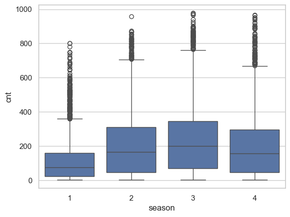

```python
# Boite à moustaches du nombre de locations par saison
sns.boxplot(x='season', y='cnt', data=df)
plt.show()
```

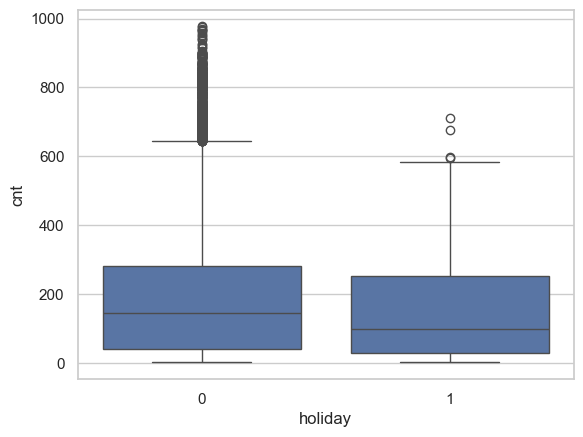

```python
# Boite à moustaches du nombre de locations par saison
sns.boxplot(x='holiday', y='cnt', data=df, )
plt.show()
```

Ces boites à moustaches montrent qu'il y a moins de location pendant les vacances. Mais avec de nombreuses valeurs extrèmes.

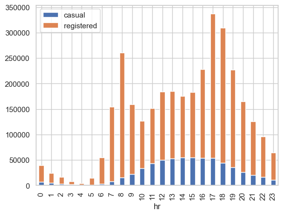

```python
# Diagramme à barres empilées des locations par heure et type d'utilisateur
df.groupby('hr')[['casual', 'registered']].sum().plot(kind='bar', stacked=True)
plt.show()
```

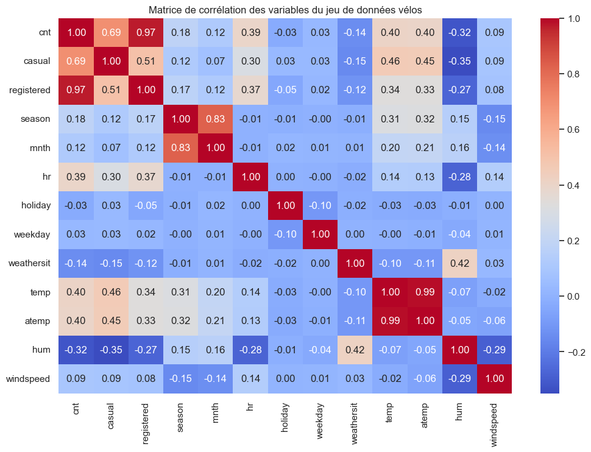

```python
# Matrice de corrélation
col = ["cnt",  "casual", "registered", "season", "mnth", "hr", "holiday", "weekday","weathersit", "temp", "atemp", "hum", "windspeed"]
plt.figure(figsize=(12, 8))
sns.heatmap(df[col].corr(), annot=True, cmap='coolwarm', fmt=".2f")
# Ajouter un titre
plt.title('Matrice de corrélation des variables du jeu de données vélos')
plt.show()
```

**Problème de colinéarité détecté :** On remarque une colinéarité extrême entre temp et atemp (corrélation = 0.99). Ces deux variables fournissent la même information. Il faut supprimer l'une d'entre elle pour améliorer les performances prédictives

Je garde `temp` (température réelle)

**7) Proposez une visualisation pertinente à partir d'une approche non-supervisée**

Une approche non-supervisée pertinente serait de faire une PCA pour visualiser quelles variables expliquent le mieux la variance. Elle permet de décorrélé les variables et de réduire le nombre de dimensions pour ne retenir que les variables pertientes. Nous devons d'abord traiter les valeurs manquantes pour faire notre PCA.

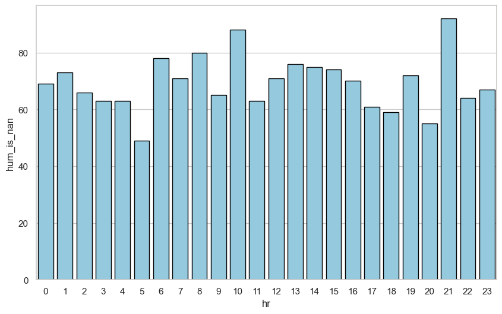

```python
# Créer une colonne binaire indiquant si 'hum' est NaN
df['hum_is_nan'] = df['hum'].isna().astype(int)

# Compter le nombre de NaN par heure
nan_by_hour = df.groupby('hr')['hum_is_nan'].sum().reset_index()

# Tracer le barplot
plt.figure(figsize=(10, 6))
sns.barplot(
    data=nan_by_hour,
    x='hr',           # Heure de la journée
    y='hum_is_nan',   # Nombre de NaN pour cette heure
    color='skyblue',  # Couleur des barres
    edgecolor='black' # Contour des barres
)

plt.show()
```

Avant de faire une PCA, nous devons traiter le problème des valeurs manquantes. L'idéal serait d'aller chercher des données supplémentaires sur une source alternative. Cela serait faisable avec les API des sites météos à condition de connaître l'emplacement où les mesures on été faites. Malheureusement ce n'est pas le cas ici. On va donc chercher une méthode d'imputation en ajoutant tout de même une colonne pour indiquer que la valeur Hum était manquante. Au dessus la distribution nous indique que les données manquantes sont assez également réparties. Grâce à la granularité par heure on a quand même un niveau de précision suffisant pour capter une tendance sur quelques heures. D'autant plus que ces données manquantes ne représentent que 10% du dataset et seule la colonne hum est concernée. Il faut donc garder cette donnée qui est tout à fait pertinente pour notre analyse.

```python
df[df['hum'].isna()].head(20)
```

|  | instant | dteday | season | mnth | hr | holiday | weekday | weathersit | temp | atemp | hum | windspeed | casual | registered | cnt | hum_is_nan |
| --- | --- | --- | --- | --- | --- | --- | --- | --- | --- | --- | --- | --- | --- | --- | --- | --- |
| 7 | 8 | 2011-01-01 | 1 | 1 | 7 | 0 | 6 | 1 | 8.20 | 12.880 | NaN | 0.0000 | 1 | 2 | 3 | 1 |
| 11 | 12 | 2011-01-01 | 1 | 1 | 11 | 0 | 6 | 1 | 14.76 | 16.665 | NaN | 19.0012 | 26 | 30 | 56 | 1 |
| 13 | 14 | 2011-01-01 | 1 | 1 | 13 | 0 | 6 | 2 | 18.86 | 22.725 | NaN | 19.9995 | 47 | 47 | 94 | 1 |
| 15 | 16 | 2011-01-01 | 1 | 1 | 15 | 0 | 6 | 2 | 18.04 | 21.970 | NaN | 19.9995 | 40 | 70 | 110 | 1 |
| 25 | 26 | 2011-01-02 | 1 | 1 | 1 | 0 | 0 | 2 | 18.04 | 21.970 | NaN | 16.9979 | 1 | 16 | 17 | 1 |
| 26 | 27 | 2011-01-02 | 1 | 1 | 2 | 0 | 0 | 2 | 17.22 | 21.210 | NaN | 19.0012 | 1 | 8 | 9 | 1 |
| 72 | 73 | 2011-01-04 | 1 | 1 | 4 | 0 | 2 | 1 | 5.74 | 9.090 | NaN | 6.0032 | 0 | 2 | 2 | 1 |
| 74 | 75 | 2011-01-04 | 1 | 1 | 6 | 0 | 2 | 1 | 4.92 | 7.575 | NaN | 7.0015 | 0 | 36 | 36 | 1 |
| 77 | 78 | 2011-01-04 | 1 | 1 | 9 | 0 | 2 | 1 | 6.56 | 7.575 | NaN | 15.0013 | 2 | 98 | 100 | 1 |
| 78 | 79 | 2011-01-04 | 1 | 1 | 10 | 0 | 2 | 2 | 6.56 | 6.820 | NaN | 22.0028 | 5 | 37 | 42 | 1 |
| 81 | 82 | 2011-01-04 | 1 | 1 | 13 | 0 | 2 | 1 | 9.84 | 11.365 | NaN | 12.9980 | 18 | 79 | 97 | 1 |
| 87 | 88 | 2011-01-04 | 1 | 1 | 19 | 0 | 2 | 1 | 9.84 | 12.880 | NaN | 7.0015 | 2 | 110 | 112 | 1 |
| 90 | 91 | 2011-01-04 | 1 | 1 | 22 | 0 | 2 | 1 | 9.02 | 12.880 | NaN | 6.0032 | 1 | 34 | 35 | 1 |
| 96 | 97 | 2011-01-05 | 1 | 1 | 5 | 0 | 3 | 1 | 9.02 | 11.365 | NaN | 11.0014 | 0 | 3 | 3 | 1 |
| 122 | 123 | 2011-01-06 | 1 | 1 | 8 | 0 | 4 | 1 | 6.56 | 11.365 | NaN | 0.0000 | 3 | 216 | 219 | 1 |
| 127 | 128 | 2011-01-06 | 1 | 1 | 13 | 0 | 4 | 1 | 10.66 | 13.635 | NaN | 7.0015 | 12 | 55 | 67 | 1 |
| 130 | 131 | 2011-01-06 | 1 | 1 | 16 | 0 | 4 | 1 | 10.66 | 12.880 | NaN | 11.0014 | 12 | 74 | 86 | 1 |
| 152 | 153 | 2011-01-07 | 1 | 1 | 15 | 0 | 5 | 2 | 8.20 | 10.605 | NaN | 11.0014 | 9 | 63 | 72 | 1 |
| 158 | 159 | 2011-01-07 | 1 | 1 | 21 | 0 | 5 | 1 | 7.38 | 9.850 | NaN | 8.9981 | 0 | 39 | 39 | 1 |
| 163 | 164 | 2011-01-08 | 1 | 1 | 2 | 0 | 6 | 2 | 7.38 | 12.120 | NaN | 0.0000 | 3 | 13 | 16 | 1 |

```python
nb_day_nan = df.groupby("dteday")["hum_is_nan"].sum()
```

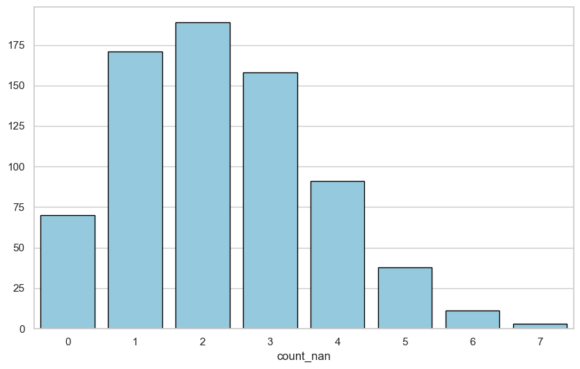

```python
#Convertir en DataFrame pour faciliter la manipulation
distribution_nan = nb_day_nan.reset_index(name="count_nan")

# Compter le nombre de jours pour chaque nombre de NaN
value_counts = distribution_nan["count_nan"].value_counts().sort_index()

# Tracer le barplot
plt.figure(figsize=(10, 6))
sns.barplot(
    x=value_counts.index,  # Nombre de NaN (abscisse)
    y=value_counts.values, # Nombre de jours (ordonnée)
    color="skyblue",
    edgecolor="black"
)
plt.show()
```

La distribution des valeurs manquantes nous montre que très peux de jours ont un nombre de valeur manquante supérieur à 4. Une possibilité serait d'imputer ces valeurs par demi-journée par exemple comme c'est le cas dans la météo classique.

Voici en référence ces méthodes présentées : https://towardsdatascience.com/missing-value-imputation-explained-a-visual-guide-with-code-examples-for-beginners-93e0726284eb/

```python
# KNN imputation for 'hum' variable
from sklearn.impute import KNNImputer


# Sélectionner les colonnes pertinentes pour l'imputation
knn_features = df[['temp', 'season', 'atemp', 'windspeed', 'hr', 'hum']]

# Initialiser KNNImputer
knn_imputer = KNNImputer(n_neighbors=5)

# Appliquer l'imputation KNN
df_imputed_knn = pd.DataFrame(
    knn_imputer.fit_transform(knn_features),
    columns=knn_features.columns
)

# Mettre à jour la colonne 'hum' dans le DataFrame original
df['hum'] = df_imputed_knn['hum']
```

Après avoir fait l'imputation il faut voir si celle-ci n'a pas significativement modifié la distribution de nos variables ainsi que la corrélation entre les variables

```python
# Plus aucune valeurs manquantes dans le dataset
df.isna().sum()
```

```
instant       0
dteday        0
season        0
mnth          0
hr            0
holiday       0
weekday       0
weathersit    0
temp          0
atemp         0
hum           0
windspeed     0
casual        0
registered    0
cnt           0
hum_is_nan    0
dtype: int64
```

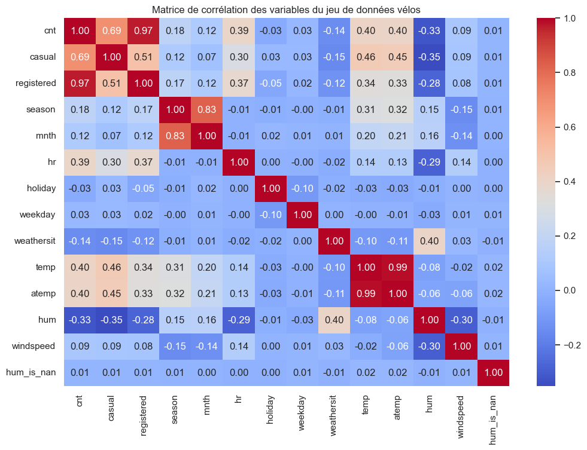

```python
col = ["cnt",  "casual", "registered", "season", "mnth", "hr", "holiday", "weekday","weathersit", "temp", "atemp", "hum", "windspeed", "hum_is_nan"]
# matrice des corrélations
plt.figure(figsize=(12, 8))
sns.heatmap(df[col].corr(), annot=True, cmap='coolwarm', fmt=".2f")
# Ajouter un titre
plt.title('Matrice de corrélation des variables du jeu de données vélos')
plt.show()
```

Les corrélations avec la variable hum ont très peu bougées. On peut donc estimer que cette méthode est pertinente pour notre cas.

```python
# PCA

from sklearn.preprocessing import StandardScaler
from sklearn.decomposition import PCA
import matplotlib.pyplot as plt
import plotly.express as px

# Sélection des variables pertinentes (les mesures physiques)
X = df[['temp', 'atemp', 'hum', 'windspeed']]
y = df['cnt']

# Standardisation des données
scaler = StandardScaler()
X_scaled = scaler.fit_transform(X)

# Application de l'ACP
pca = PCA()
X_pca = pca.fit_transform(X_scaled)

# Visualisation des résultats
'''plt.figure(figsize=(10, 6))
plt.scatter(X_pca[:, 0], X_pca[:, 1], alpha=0.5)
plt.title('ACP des données de locations de vélos')
plt.xlabel('Composante Principale 1')
plt.ylabel('Composante Principale 2')
plt.grid(True)
plt.show()

# Variance expliquée
print("Variance expliquée :", pca.explained_variance_ratio_)
exp_var_cumul = np.cumsum(pca.explained_variance_ratio_)
'''
exp_var_cumul = np.cumsum(pca.explained_variance_ratio_)

px.area(
    x=range(1, exp_var_cumul.shape[0] + 1),
    y=exp_var_cumul,
    labels={"x": "# Components", "y": "Explained Variance"}
)
```

[output not shown]

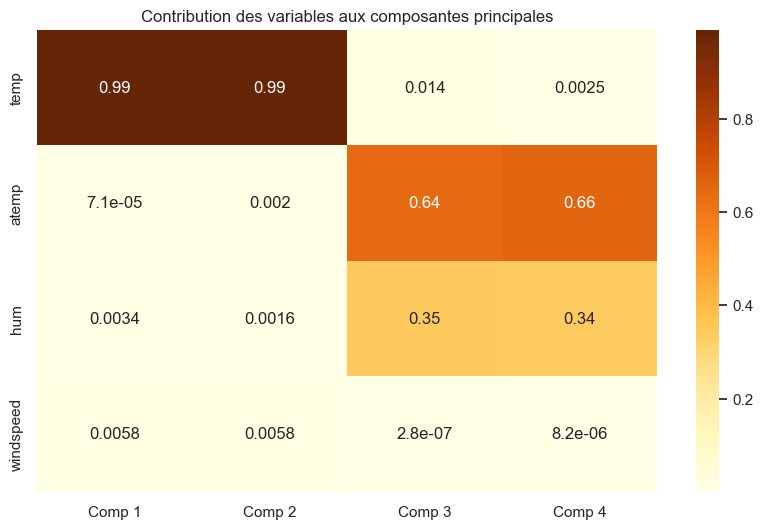

```python
variables = X.columns

# Contribution des variables aux composantes
contributions = pca.components_**2 * pca.explained_variance_[:, np.newaxis]

# Normaliser pour obtenir des proportions
contributions = contributions / contributions.sum(axis=0)

# Tracer la heatmap
plt.figure(figsize=(10, 6))
sns.heatmap(
    contributions,
    annot=True,
    cmap='YlOrBr',
    xticklabels=[f"Comp {i+1}" for i in range(4)],
    yticklabels=variables
)
plt.title("Contribution des variables aux composantes principales")
plt.show()
```

On a donc les 3 variables (hum, temp et atemp) qui expliquent 99% de la variance tandis que windspeed a peu d'impact.

## Feature Engineering

**8) Ajoutez à ce dataset une "feature" qui vous semble pertinente. Comment pouvez-vous évaluer l'apport potentiel de cette feature ? Montrez les graphiques ou tableaux pertinents pour appuyer votre réponse.**

Mon approche : Feature Engineering temporel

Objectifs:

1. Capturer la saisonnalité annuelle continue via day_of_year (plus précis que mnth)
2. Capturer la tendance long terme (augmentation du trafic au fil du temps)
3. Capturer les schémas temporels importants (jours de travail vs jours spéciaux)

Je conserve l'encodage catégorique pour hr, mnth, weekday car il y a des pics d'utilisation spécifiques à certaines heures que les modèles arborescents exploitent bien d'après la source en dessous.

source : https://towardsdatascience.com/cyclical-encoding-an-alternative-to-one-hot-encoding-for-time-series-features-4db46248ebba/

```python
# Convertir dteday en datetime
df['dteday'] = pd.to_datetime(df['dteday'])

# 1. Jour de l'année (1-365) : capture la saisonnalité annuelle continue
df['day_of_year'] = df['dteday'].dt.dayofyear

# 2. Jours depuis le début : capture la tendance long terme
df['days_since_start'] = (df['dteday'] - df['dteday'].min()).dt.days

# 3. Est-ce un jour de travail ? (pas week-end ET pas férié)
df['is_business_day'] = ((df['weekday'] != 0) & (df['weekday'] != 6) & (df['holiday'] == 0)).astype(int)

# 4. Est-ce une heure de pointe ? (plus de 400 locations en médiane)
# Calculer la médiane par heure
hourly_median = df.groupby('hr')['cnt'].median()
peak_threshold = 400
peak_hours = hourly_median[hourly_median > peak_threshold].index.tolist()
df['is_peak_hour'] = df['hr'].isin(peak_hours).astype(int)

print("Features créées :")
print(df[['dteday', 'day_of_year', 'days_since_start', 'is_business_day', 'is_peak_hour']].head(10))
print(f"\nJours de l'année : {df['day_of_year'].min()} à {df['day_of_year'].max()}")
print(f"Jours depuis le début : {df['days_since_start'].min()} à {df['days_since_start'].max()}")
print(f"Distribution is_business_day : {df['is_business_day'].value_counts().to_dict()}")
print(f"\nHeures de pointe (médiane > {peak_threshold}) : {peak_hours}")
print(f"Distribution is_peak_hour : {df['is_peak_hour'].value_counts().to_dict()}")
```

```
Features créées :
      dteday  day_of_year  days_since_start  is_business_day  is_peak_hour
0 2011-01-01            1                 0                0             0
1 2011-01-01            1                 0                0             0
2 2011-01-01            1                 0                0             0
3 2011-01-01            1                 0                0             0
4 2011-01-01            1                 0                0             0
5 2011-01-01            1                 0                0             0
6 2011-01-01            1                 0                0             0
7 2011-01-01            1                 0                0             0
8 2011-01-01            1                 0                0             0
9 2011-01-01            1                 0                0             0

Jours de l'année : 1 à 366
Jours depuis le début : 0 à 730
Distribution is_business_day : {1: 11865, 0: 5514}

Heures de pointe (médiane > 400) : [17, 18]
Distribution is_peak_hour : {0: 15921, 1: 1458}
```

```python
# Évaluation : corrélations des nouvelles features

corr_new_features = df[['cnt', 'day_of_year', 'days_since_start', 'is_business_day', 'is_peak_hour']].corr()['cnt'].drop('cnt')

print("Corrélations des nouvelles features avec cnt")
print(corr_new_features.abs().sort_values(ascending=False))
print("\n" + "="*60)
print("Impact de is_peak_hour :")
print(f"  Corrélation : {corr_new_features['is_peak_hour']:.4f}")
print(f"  Médiane cnt (heures normales) : {df[df['is_peak_hour']==0]['cnt'].median():.0f}")
print(f"  Médiane cnt (heures de pointe) : {df[df['is_peak_hour']==1]['cnt'].median():.0f}")
```

```
Corrélations des nouvelles features avec cnt
is_peak_hour        0.423844
days_since_start    0.277753
day_of_year         0.120105
is_business_day     0.030284
Name: cnt, dtype: float64

============================================================
Impact de is_peak_hour :
  Corrélation : 0.4238
  Médiane cnt (heures normales) : 126
  Médiane cnt (heures de pointe) : 446
```

On remarque que la 1ère et la 2è variable appportent une information supplémentaire comme on le voit avec le coefficient de corrélation.

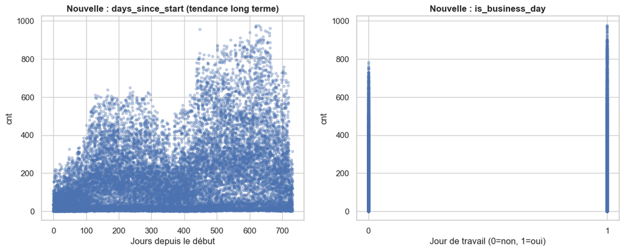

```python
# Visualisation : impact des nouvelles features

fig, axes = plt.subplots(1, 2, figsize=(14, 5))

# Tendance long terme
axes[0].scatter(df['days_since_start'], df['cnt'], alpha=0.3, s=10)
axes[0].set_title('Nouvelle : days_since_start (tendance long terme)', fontsize=12, fontweight='bold')
axes[0].set_xlabel('Jours depuis le début')
axes[0].set_ylabel('cnt')


# Business day
axes[1].scatter(df['is_business_day'], df['cnt'], alpha=0.3, s=10)
axes[1].set_title('Nouvelle : is_business_day', fontsize=12, fontweight='bold')
axes[1].set_xlabel('Jour de travail (0=non, 1=oui)')
axes[1].set_ylabel('cnt')
axes[1].set_xticks([0, 1])
plt.show()
```

**Conclusions sur le Feature Engineering :**

Ces features temporelles apportent plusieurs améliorations :

1. **day_of_year** : Capture la saisonnalité continue sur les 365 jours. Plus informatif que `mnth` qui agrège par mois.
2. **days_since_start** : Capture la tendance long terme On découvre ainsi qu'il y a une augmentation du trafic au fil du temps.
3. **is_business_day** : Combine `holiday` et `weekday` pour isoler tous les jours de travail où le comportement est différent comme on a pu le voir plus tôt.
4. **Conservation de l'encodage catégorique** pour hr, mnth, weekday : Ces variables ont des pics d'utilisation très spécifiques (ex: 8h et 17h pour les trajets domicile-travail). Les modèles arborescents (Random Forest, Gradient Boosting) exploitent cet aspect comme on a pu le voir dans la source au dessus.

## Algorithmes et Validation (entraînement de l'algorithme prédictif)

Dans cette partie, vous allez entraîner un modèle prédictif pour prédire le nombre total de locations de vélos. **Utilisez la librairie sklearn** et lisez attentivement la documentation des fonctions que vous serez amenés à choisir. De manière générale, **commencez simple** et vous pourrez améliorer votre modèle dans la partie suivante, ou donner vos pistes de réflexion à la fin de ce TP.

**9) Séparez au sein du dataset vos jeux d'entraînement et de test. A quoi cette étape sert-elle ?**

**Importance de la séparation train/test :**

Cette étape permet de :

Évaluer la performance du modèle sur des données qu'il ne connait pas (test) pour éviter l'overfitting (modèle trop adapté aux données d’entraînement).

Détecter des biais : Si le modèle performe bien en train mais mal en test, il y a un problème de généralisation.

Comparer des algorithmes de manière objective (ex. : régression linéaire vs Random Forest).

On ourrait aussi ajuster les hyperparamètres (via un jeu de validation extrait du train).

Valider la performance avant déploiement

**Méthodes appliquées :**

- Proportions : 80% train, 20% test
- `random_state` constant pour la reproductibilité
- Les catégories sont conservées (pas de problème de leakage)

```python
from sklearn.model_selection import train_test_split

# Préparer les features (X) et la cible (y)
# Exclure : cnt (cible), casual et registered (fuite de données), dteday (redondant avec day_of_year)
# Eclure aussi (colinéarité avec temp)
features_to_exclude = ['cnt','atemp', 'casual', 'registered', 'dteday', 'instant']
X = df.drop(columns=features_to_exclude)
y = df['cnt']

print("Shape avant séparation :")
print(f"X : {X.shape}")
print(f"y : {y.shape}")
print(f"\nVariables utilisées : {list(X.columns)}")

# Séparation train/test (80/20)
X_train, X_test, y_train, y_test = train_test_split(
    X, y,
    test_size=0.2,           # 20% pour le test
    random_state=42          # Pour la reproductibilité
)

print(f"\n\nAprès séparation :")
print(f"Train : {X_train.shape[0]} samples")
print(f"Test  : {X_test.shape[0]} samples")
```

```
Shape avant séparation :
X : (17379, 14)
y : (17379,)

Variables utilisées : ['season', 'mnth', 'hr', 'holiday', 'weekday', 'weathersit', 'temp', 'hum', 'windspeed', 'hum_is_nan', 'day_of_year', 'days_since_start', 'is_business_day', 'is_peak_hour']


Après séparation :
Train : 13903 samples
Test  : 3476 samples
```

**10) Choisissez un modèle et indiquez les raisons de ce choix. Si des pré-traitements spécifiques sont nécessaires à la bonne exécution et performance de l'algorithme, vous les effectuerez ici en indiquant pourquoi ils sont nécessaires. Vous pourrez ensuite procéder à l'entraînement de votre modèle à l'aide de la fonction *fit* présente sur l'ensemble des estimateurs sklearn**

**Choix du modèle : Régression Linéaire Multiple**

**Justification :**

1. On veut prédire une variable continue **cnt** en fonction d'un historique de données asssociant les variables explicatives à la valeur connue de la cible : les méthodes de régression sont donc toutes indiquées. La régression multiple gère les variables catégorielles encodées
2. Simplicité: C'est un bon point de départ pour comprendre les relations entre variables et la cible
3. Interprétabilité : Les coefficients indiquent directement l'impact de chaque variable sur le nombre de locations
4. Baseline : Permet de comparer avec des modèles plus complexes (Random Forest, Gradient Boosting)

**Pré-traitements nécessaires** :

- One-Hot Encoding : Convertir les variables catégorielles (hr, mnth, weekday, season, holiday, weathersit) en variables binaires
- Pas de standardisation : La régression linéaire peut fonctionner avec des échelles différentes, mais je standardiserais plus tard si nécessaire

```python
from sklearn.linear_model import LinearRegression

# Les variables catégorielles sont déjà encodées numériquement dans le CSV
# (season: 1-4, mnth: 1-12, hr: 0-23, etc.)
# On doit les convertir en variables binaires pour la régression linéaire

X_train_encoded = pd.get_dummies(X_train, columns=['season', 'mnth', 'hr', 'holiday', 'weekday', 'weathersit'], drop_first=True)
X_test_encoded = pd.get_dummies(X_test, columns=['season', 'mnth', 'hr', 'holiday', 'weekday', 'weathersit'], drop_first=True)

# Aligner les colonnes (test peut avoir des catégories manquantes)
X_test_encoded = X_test_encoded.reindex(columns=X_train_encoded.columns, fill_value=0)

print(f"Dimensions après One-Hot Encoding :")
print(f"X_train : {X_train_encoded.shape}")
print(f"X_test : {X_test_encoded.shape}")
print(f"Nombre de features : {X_train_encoded.shape[1]}")

# Création et entraînement du modèle
model_lr = LinearRegression()
model_lr.fit(X_train_encoded, y_train)

print(f"\n=== Modèle Régression Linéaire Multiple ===")
print(f"Coefficients (top 10 en valeur absolue) :")

# Afficher les 10 plus grands coefficients
coef_df = pd.DataFrame({
    'Feature': X_train_encoded.columns,
    'Coefficient': model_lr.coef_
})
coef_df['Abs_Coef'] = coef_df['Coefficient'].abs()
print(coef_df.nlargest(10, 'Abs_Coef')[['Feature', 'Coefficient']])

print(f"\nIntercept : {model_lr.intercept_:.2f}")
```

```
Dimensions après One-Hot Encoding :
X_train : (13903, 55)
X_test : (3476, 55)
Nombre de features : 55

=== Modèle Régression Linéaire Multiple ===
Coefficients (top 10 en valeur absolue) :
         Feature  Coefficient
29          hr_8   316.757674
7   is_peak_hour   241.475238
40         hr_19   235.734340
37         hr_16   225.536957
33         hr_12   176.569137
28          hr_7   172.443784
34         hr_13   171.775025
30          hr_9   164.492122
41         hr_20   159.843080
36         hr_15   159.478883

Intercept : -71.61
```

**11) Ce premier modèle est-il performant ? Comment mesurez-vous sa performance et pourquoi ?**

```python
from sklearn.metrics import r2_score, mean_squared_error, mean_absolute_error
import numpy as np

# Prédictions
y_train_pred = model_lr.predict(X_train_encoded)
y_test_pred = model_lr.predict(X_test_encoded)

# Métriques
r2_train = r2_score(y_train, y_train_pred)
r2_test = r2_score(y_test, y_test_pred)
rmse_test = np.sqrt(mean_squared_error(y_test, y_test_pred))
mae_test = mean_absolute_error(y_test, y_test_pred)

print("=== PERFORMANCE ===\n")
print(f"R² Train : {r2_train:.4f}")
print(f"R² Test  : {r2_test:.4f}")
print(f"RMSE Test : {rmse_test:.2f} vélos")
print(f"MAE Test  : {mae_test:.2f} vélos")
print(f"Erreur relative : {(rmse_test / y_test.mean() * 100):.1f}%")
```

```
=== PERFORMANCE ===

R² Train : 0.6870
R² Test  : 0.6810
RMSE Test : 100.50 vélos
MAE Test  : 74.01 vélos
Erreur relative : 54.3%
```

- Ce modèle a une bonne capacité de généralisation car le R² entre le train et le test est quasi similaire
- Il a une performance correcte avec 68% de la variance expliquée. Un bon modèle aurait un R² au dessus de 0,7
- Le Root Mean Square Error et la Men Absolute Error permettent de mesurer l'erreur de prédiction. On voit que celle-ci est relativement importante car cela représente environ 54.3% d'erreur relative par rapport à la moyenne de y_test. Notre modèle a du mal à saisir la variabilité des données.

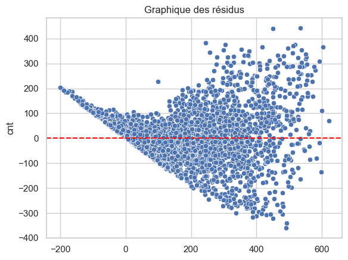

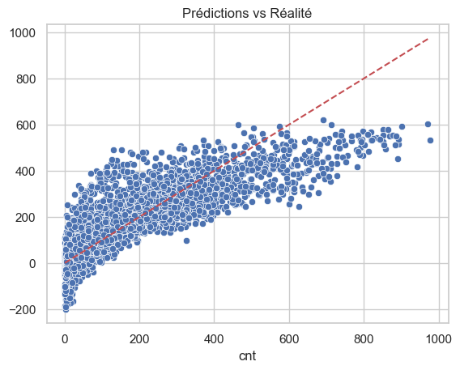

```python
# Résidus
residus = y_test - y_test_pred
sns.scatterplot(x=y_test_pred, y=residus)
plt.axhline(0, color='red', ls='--')
plt.title("Graphique des résidus")
plt.show()

# Prédictions vs Réalité
sns.scatterplot(x=y_test, y=y_test_pred)
plt.plot([y_test.min(), y_test.max()], [y_test.min(), y_test.max()], 'r--')
plt.title("Prédictions vs Réalité")
plt.show()
```

Le tracé des résiduals qui sont la différence entre yreel et y prédit nous confirme que le modèle a du mal à prédire les données lorsque **cnt** augmente.

## Améliorer le modèle

**12) Quelles données supplémentaires permettraient d’avoir une prédiction plus précise ? De quelles données aurait-on besoin pour assurer la maintenance complète des bornes de location ?**

Comme on l'a déjà dit, les données météos manquantes auraient été utiles.

On aurait aussi pu ajouter des données liées aux pannes du service ou bien à la maintenance des vélos. L'utilisateur peut généralement affiché une fois arrivée à la borne si un vélo a un problème.

On aurait aussi pu ajouter le nombre de vélo disponibles par station avec le pourcentage utilisé. Cela permettrait de s'assurer de la bonne répartition de ceux-ci pour que des usagers potentiels ne se retrouvent pas sans vélo.

Il aurait aussi été possible d'ajouter le type de vélo (électrique ou musculaire), car certains trajets peuvent expliquer une moindre utilisation dénivelé etc.

**13) Mettez en place les techniques de régularisation adaptées à l’algorithme choisi**

**Régularisation L2 (Ridge Regression)**

**Justification :**

- **Standardisation** : La regression Ridge est sensible à l'échelle des features. StandardScaler transforme toutes les variables pour avoir une moyenne=0 et écart_type=1
- **Régularisation L2** : Ajoute une pénalité sur la somme des carrés des coefficients pour éviter les gros coefficients
- **Effet** : Réduit le surapprentissage et améliore la généralisation
- **Hyperparamètre alpha** : Contrôle la force de la pénalité (alpha=0 = régression linéaire classique)

```python
from sklearn.preprocessing import StandardScaler
from sklearn.linear_model import Ridge
from sklearn.pipeline import Pipeline

# Standardisation des données
scaler_train = StandardScaler()
X_train_scaled = scaler_train.fit_transform(X_train_encoded)

scaler_test = StandardScaler()
X_test_scaled = scaler_test.fit_transform(X_test_encoded)

print("Données standardisées :")
print(f"X_train_scaled mean : {X_train_scaled.mean(axis=0)[:5]} (devrait ≈ 0)")
print(f"X_train_scaled std : {X_train_scaled.std(axis=0)[:5]} (devrait ≈ 1)")

# Ridge regression avec alpha=1.0
model_ridge = Ridge(alpha=1.0, random_state=42)
model_ridge.fit(X_train_scaled, y_train)

# Prédictions
y_train_pred_ridge = model_ridge.predict(X_train_scaled)
y_test_pred_ridge = model_ridge.predict(X_test_scaled)

# Métriques
from sklearn.metrics import r2_score, mean_squared_error, mean_absolute_error

r2_train_ridge = r2_score(y_train, y_train_pred_ridge)
r2_test_ridge = r2_score(y_test, y_test_pred_ridge)
rmse_test_ridge = np.sqrt(mean_squared_error(y_test, y_test_pred_ridge))

print(f"\n=== Ridge Regression (alpha=1.0) ===")
print(f"R² Train : {r2_train_ridge:.4f}")
print(f"R² Test  : {r2_test_ridge:.4f}")
print(f"RMSE Test : {rmse_test_ridge:.2f} vélos")
```

```
Données standardisées :
X_train_scaled mean : [2.85688980e-16 4.08857217e-18 2.27937898e-16 2.14650039e-17
 9.45482314e-18] (devrait ≈ 0)
X_train_scaled std : [1. 1. 1. 1. 1.] (devrait ≈ 1)

=== Ridge Regression (alpha=1.0) ===
R² Train : 0.6870
R² Test  : 0.6788
RMSE Test : 100.86 vélos
```

**Régularisation L1 (Lasso)**

**Justification :**

- **Standardisation** : StandardScaler transforme toutes les variables pour avoir moyenne=0 et std=1
- **Régularisation L1** : Permet d'annuler des coefficients et de retenir un modèle plus parcimonieux.
- **Effet** : Réduit le surapprentissage et améliore la généralisation. Réduit le nombre de variables.
- **Hyperparamètre alpha** : Contrôle la force de la pénalité (alpha=0 = régression linéaire classique)

```python
from sklearn.linear_model import Lasso

# Lasso regression avec alpha=1.0
model_lasso = Lasso(alpha=1.0, random_state=42, max_iter=100000, tol=1e-4)
model_lasso.fit(X_train_scaled, y_train)

# Prédictions
y_train_pred_lasso = model_lasso.predict(X_train_scaled)
y_test_pred_lasso = model_lasso.predict(X_test_scaled)

# Métriques
r2_train_lasso = r2_score(y_train, y_train_pred_lasso)
r2_test_lasso = r2_score(y_test, y_test_pred_lasso)
rmse_test_lasso = np.sqrt(mean_squared_error(y_test, y_test_pred_lasso))

print(f"\n=== Lasso Regression (alpha=1.0) ===")
print(f"R² Train : {r2_train_lasso:.4f}")
print(f"R² Test  : {r2_test_lasso:.4f}")
print(f"RMSE Test : {rmse_test_lasso:.2f} vélos")
print(f"Nombre de coefficients non-nuls : {np.sum(model_lasso.coef_ != 0)}")

print(f"\n=== Comparaison Régression Linéaire vs Ridge vs Lasso ===")
print(f"Régression linéaire - R² Test : {r2_test:.4f}, RMSE : {rmse_test:.2f}")
print(f"Ridge (alpha=1.0)   - R² Test : {r2_test_ridge:.4f}, RMSE : {rmse_test_ridge:.2f}")
print(f"Lasso (alpha=1.0)   - R² Test : {r2_test_lasso:.4f}, RMSE : {rmse_test_lasso:.2f}")
```

```
=== Lasso Regression (alpha=1.0) ===
R² Train : 0.6822
R² Test  : 0.6763
RMSE Test : 101.25 vélos
Nombre de coefficients non-nuls : 44

=== Comparaison Régression Linéaire vs Ridge vs Lasso ===
Régression linéaire - R² Test : 0.6810, RMSE : 100.50
Ridge (alpha=1.0)   - R² Test : 0.6788, RMSE : 100.86
Lasso (alpha=1.0)   - R² Test : 0.6763, RMSE : 101.25
```

# Analyse des résultats :

Notre modèle de base est plus performant sans les méthodes de régularisation comme on peut le voir avec le R² 0.6810 et le RMSE de 100.50 Cela est certainement dû au fait que les régularisation réduisent l'impact des variables prédictives les plus importantes

**14) Mettez en place le choix des meilleurs hyperparamètres**

```python
from sklearn.model_selection import GridSearchCV

# Grille d'hyperparamètres pour Ridge
param_grid = {
    'alpha': [0.001, 0.01, 0.1, 1.0, 10.0, 100.0, 1000.0]
}

# GridSearchCV avec 5-fold cross-validation
ridge_cv = Ridge()
grid_search = GridSearchCV(ridge_cv, param_grid, cv=5, scoring='neg_root_mean_squared_error', return_train_score=True)
grid_search.fit(X_train_scaled, y_train)

# Résultats
cv_results = pd.DataFrame(grid_search.cv_results_)

# Vérifier les colonnes disponibles
print("Colonnes disponibles :", cv_results.columns.tolist())

# Extraire les colonnes correctes
results_summary = cv_results[['param_alpha', 'mean_train_score', 'mean_test_score', 'std_test_score']].copy()
results_summary.columns = ['Alpha', 'Mean Train R²', 'Mean Test R²', 'Std Test R²']
results_summary = results_summary.sort_values('Alpha').reset_index(drop=True)

print("=== Résultats GridSearchCV Ridge (5-fold CV) ===\n")
print(results_summary.to_string(index=False))

print(f"\n Meilleur alpha : {grid_search.best_params_['alpha']}")
print(f"   Meilleur R² CV : {grid_search.best_score_:.4f}")

# Évaluer sur test avec le meilleur modèle
y_test_pred_best = grid_search.best_estimator_.predict(X_test_scaled)
r2_test_best = r2_score(y_test, y_test_pred_best)
rmse_test_best = np.sqrt(mean_squared_error(y_test, y_test_pred_best))

print(f"\n=== Performance sur Test ===")
print(f"R² Test (meilleur alpha) : {r2_test_best:.4f}")
print(f"RMSE Test : {rmse_test_best:.2f} vélos")
```

[output not shown]

```python
# GridSearchCV pour Lasso
# Note: Reduced alpha grid (fewer values) and increased tolerance for faster convergence
param_grid_lasso = {
    'alpha': [0.1, 1.0, 10.0, 100.0]
}

# GridSearchCV avec 5-fold cross-validation
# Using 'saga' solver is faster than default for Lasso with many features
lasso_cv = Lasso(random_state=42, max_iter=50000, tol=1e-3, warm_start=False)
grid_search_lasso = GridSearchCV(lasso_cv, param_grid_lasso, cv=5, scoring='neg_root_mean_squared_error', return_train_score=True, n_jobs=-1)
grid_search_lasso.fit(X_train_scaled, y_train)

# Résultats
cv_results_lasso = pd.DataFrame(grid_search_lasso.cv_results_)

# Extraire les colonnes correctes
results_summary_lasso = cv_results_lasso[['param_alpha', 'mean_train_score', 'mean_test_score', 'std_test_score']].copy()
results_summary_lasso.columns = ['Alpha', 'Mean Train R²', 'Mean Test R²', 'Std Test R²']
results_summary_lasso = results_summary_lasso.sort_values('Alpha').reset_index(drop=True)

print("\n=== Résultats GridSearchCV Lasso (5-fold CV) ===\n")
print(results_summary_lasso.to_string(index=False))

print(f"\n Meilleur alpha : {grid_search_lasso.best_params_['alpha']}")
print(f"   Meilleur R² CV : {grid_search_lasso.best_score_:.4f}")

# Évaluer sur test avec le meilleur modèle
y_test_pred_lasso_best = grid_search_lasso.best_estimator_.predict(X_test_scaled)
r2_test_lasso_best = r2_score(y_test, y_test_pred_lasso_best)
rmse_test_lasso_best = np.sqrt(mean_squared_error(y_test, y_test_pred_lasso_best))
non_zero_coef_lasso = np.sum(grid_search_lasso.best_estimator_.coef_ != 0)

print(f"\n=== Performance sur Test ===")
print(f"R² Test (meilleur alpha) : {r2_test_lasso_best:.4f}")
print(f"RMSE Test : {rmse_test_lasso_best:.2f} vélos")
print(f"Nombre de coefficients non-nuls : {non_zero_coef_lasso}/{len(grid_search_lasso.best_estimator_.coef_)}")
```

[output not shown]

# Analyse des résultats

J'ai utilisé une méthode de cross valditation où les données sont divisées en sous-ensembles d’entraînement et de validation pour éviter l’overfitting

Cependant, notre modèle initial était plus performant comme on le peut voir.

**Cela peut-être dû à la pénalisation de variables réellement importantes par la régularisation.**

**15) Quelle(s) autre(s) approche(s) aurait pu être pertinente(s) ? Vous pourrez indiquer ici les pistes d'améliorations que vous envsageriez si vous étiez amené à poursuivre ce projet**

le modèle linéaire était mon modèle de base mais si je devais aller plus loin j'utiliserais des méthodes ensemblistes comme des forêts aléatoires et des gradients boostés. Ils capturent mieux les relations non linéaires et c'est pertient pour notre jeu de données dans lequel des données ont une dimension temporelle avec saisonnalité et heures de pointe. Ils peuvent aussi identifier les variables les plus influentes

Pour l'optimisation des hyper paramètres j'utiliserais une validation croisée stratifiée par jour ou heure pour mieux respecter la structure temporelle des données.

Je pourrais aussi faire un encodage cyclique des variables temporelles pour mieux saisir la saisonnalité. Ce serait pertinent avec les méthodes ensemblistes qui supportent bien cet encodage.

Enfin j'essaierais d'enrichir le jeu de données comme déjà expliqué précédemment.